# Multilevel Analysis 1(level1:individual)

CHEN MAOSEN

2025-12-19

# Description of dataset

| log.radon | basement | uranium | county | county.name |
| --- | --- | --- | --- | --- |
| 0.7885 | 1 | -0.6890 | 1 | AITKIN |
| 0.7885 | 0 | -0.6890 | 1 | AITKIN |
| 1.0647 | 0 | -0.6890 | 1 | AITKIN |
| 0.0000 | 0 | -0.6890 | 1 | AITKIN |
| 1.1314 | 0 | -0.8473 | 2 | ANOKA |

Dataset:

- **House variables:**
  - **log.radon**:Numeric. Logarithm of indoor radon measurement values
  - **basement**:Binary. Measurement position indication (0=basement/1=1st floor)
- **County variables:**
  - **county**:Factor. ID of each county with 85 levels
  - **county.name**:Factor. Name of each county
  - **uranium**:Numeric. Average uranium in the soil of each county

# Analysis method and model specification

## Random intercept model:

Level 1:$\quad Y_{ij}=\beta_{0j}+\beta_{1j}\text{Basement}_{ij}+R_{ij}\quad R_{ij}\sim\mathcal{N}(0,\sigma^2)$  
Level 2:$\quad \beta_{0j}=\gamma_1+U_j \quad U_j\sim\mathcal{N}(0,\tau_0^2)$ Combined:$\quad Y_{ij}=\gamma_1+\beta_{1j}\text{Basement}_{ij}+U_j+R_{ij}$

$Y_{ij}=\text{log.radon}_{ij}$

# Analysis method and model specification

```r
library(lme4)
Basement.fixed <- lmer(
  log.radon ~ 1 + basement + (1 | county),
  data = radon)
```

```
## Random effects:
##  Groups   Name        Variance Std.Dev.
##  county   (Intercept) 0.1077   0.3282
##  Residual             0.5709   0.7556
## Number of obs: 919, groups:  county, 85
##
## Fixed effects:
##             Estimate Std. Error t value
## (Intercept)  1.46160    0.05158  28.339
## basement    -0.69299    0.07043  -9.839
```

```
## # Intraclass Correlation Coefficient
##
##     Adjusted ICC: 0.159
##   Unadjusted ICC: 0.145
```

# Results

## Random intercept model:

By default, we use REML to estimate parameters:

$\text{log.radon}_{ij}=1.462-0.693\text{Basement}_{ij}+U_j+R_{ij}$  
$U_j\sim\mathcal{N}(0,0.108)$  
$R_{ij}\sim\mathcal{N}(0,0.571)$

## ICC

Adjusted ICC: 0.159  
Unadjusted ICC: 0.145

*Interpretation:*

- Adjusted:  
  County grouping accounts for 15.9% of the total variance of the log.radon under the control of Basement.
- Unadjusted:  
  County grouping accounts for 14.5% of the total variance of the log.radon

# Pooling

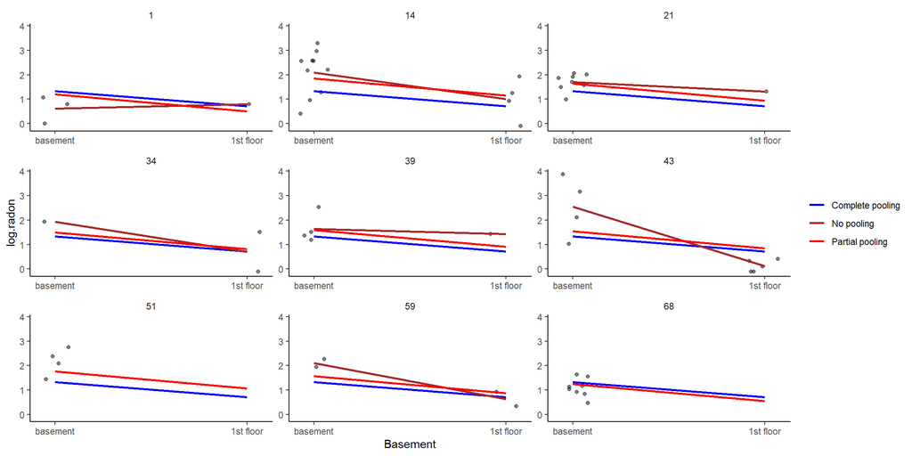

Complete pooling assumes no variance between counties, but it’s often larger.  
No pooling assumes larger variance between counties(independence), but it’s often smaller.  
Partial pooling is in between.

# Model comparison

## Different fixed part(with level 2 predictor)

Since models only have difference of fixed part, thus we **must** use ML to estimate parameters:

```r
Basement.fixed         <- lmer(log.radon ~ 1 + basement +           (1 | county), data = radon)
Uranium.Basement.fixed <- lmer(log.radon ~ 1 + basement + uranium + (1 | county), data = radon)
anova(Basement.fixed,Uranium.Basement.fixed,
      refit=TRUE)
```

```
## Data: radon
## Models:
## Basement.fixed: log.radon ~ 1 + basement + (1 | county)
## Uranium.Basement.fixed: log.radon ~ 1 + basement + uranium + (1 | county)
##                        npar    AIC    BIC  logLik -2*log(L)  Chisq Df
## Basement.fixed            4 2171.7 2190.9 -1081.8    2163.7
## Uranium.Basement.fixed    5 2132.8 2156.9 -1061.4    2122.8 40.834  1
##                        Pr(>Chisq)
## Basement.fixed
## Uranium.Basement.fixed  1.658e-10 ***
## ---
## Signif. codes:  0 '***' 0.001 '**' 0.01 '*' 0.05 '.' 0.1 ' ' 1
```

# Model comparison

## Different fixed part(with level 2 predictor)

- Test statistic: $D_0-D_1\sim\mathcal{X}_1^2$
- $D_0-D_1$=2163.7-2122.8=40.834
- $p$=P[$D_0-D_1$>40.834]<.001

## Conclusion

At $\alpha=5$%, we reject $\mathcal{M}_0$.  
Adding Uranium significantly imporves the model fit.

# Model comparison

## Different random part(with random slope)

Since models only have difference of random part, thus we **should** use REML to estimate parameters:

```r
Uranium.Basement.fixed  <- lmer(log.radon ~ 1 + basement + uranium + (1 | county), data = radon)
Uranium.Basement.random <- lmer(log.radon ~ 1 + basement + uranium + (1 + basement|county), data = radon)
anova(Uranium.Basement.fixed,Uranium.Basement.random,
      refit=FALSE)
```

```
## Data: radon
## Models:
## Uranium.Basement.fixed: log.radon ~ 1 + basement + uranium + (1 | county)
## Uranium.Basement.random: log.radon ~ 1 + basement + uranium + (1 + basement | county)
##                         npar    AIC    BIC  logLik -2*log(L)  Chisq Df
## Uranium.Basement.fixed     5 2144.2 2168.3 -1067.1    2134.2
## Uranium.Basement.random    7 2142.6 2176.4 -1064.3    2128.6 5.5459  2
##                         Pr(>Chisq)
## Uranium.Basement.fixed
## Uranium.Basement.random    0.06248 .
## ---
## Signif. codes:  0 '***' 0.001 '**' 0.01 '*' 0.05 '.' 0.1 ' ' 1
```

# Model comparison

## Conclusion

At $\alpha=5$%, we fail to reject $\mathcal{M}_0$.  
There is not enough evidence that adding random slopes for Basement imporves model fit.  
We decude to retain $\mathcal{M}_0$.